# Goal

Our goal for this exercise sheet is to build a simple machine learning pipeline using `mlr3pipelines`. The package `mlr3pipelines` helps to write machine learning workflows as directed `Graph`s that unify preprocessing and model fitting in an expressive and intuitive language. By combining preprocessing steps and model fitting, we will create a pipeline that can be used as an ordinary `mlr3` learner. Specifically, we will apply the kNN learning algorithm with multiple preprocessing steps on a dirty version of the German credit dataset.

# German Credit Dataset (dirty)

We use a dirty version of the German credit dataset of Prof. Dr. Hans Hoffman of the University of Hamburg in 1994, which contains 1000 datapoints reflecting bank customers. The dataset is available at the UCI repository as [Statlog (German Credit Data) Data Set](https://archive.ics.uci.edu/ml/datasets/Statlog+%28German+Credit+Data%29). We artificially introduced missing values and outliers in a few features.

## Preprocessing

We first load the `.csv` file from the directory.

```r
credit = read.csv("data/german_credit_dirty.csv", sep = ",", stringsAsFactors = TRUE)
```

In a previous exercise sheet, we already did an explorative analysis of the dirty `credit` dataset. First, we clean the data:

- Ages of 0 for a credit applicant are implausible and are, therefore, replaced by `NA`s.

Applying a preprocessing step as data cleaning directly to the task (which is unproblematic w.r.t. to data leakage).

```r
library("mlr3verse")
library("data.table")

task = TaskClassif$new("german_credit", backend = credit, target = "credit_risk")
fix_age = function(x) {
  x[which(x == 0L)] = NA_integer_
  x
}
preproc = po("colapply", applicator = fix_age, affect_columns = selector_name("age"))
task = preproc$train(list(task))[[1]]
```

# Exercises:

In this exercise, we will apply a k-nearest neighbour (kNN) learning algorithm to the preprocessed (dirty) credit dataset.

## Create a Filtering PipeOp

Since the kNN learner suffers from the curse of dimensionality, we want to subset our set of features to the five most important ones according to a feature filtering method based on the feature importance computed by a learning algorithm.

Set up a `PipeOp` that filters features according to the feature importance values returned by `rpart` (see `flt("importance")$help()`).

**Hint 1:**

The filter can be created by `flt("importance")` (see also its help page `flt("importance")$help()`). Note that if you don’t pass the `learner` argument in `flt`, by default the feature importance of a decision tree (`rpart`) is used. You can set up a `PipeOp` with `po()`. This filter should be the input to the `filter` argument of `po()` (see also examples in the help page `?PipeOpFilter`). To select the five most important features, you need to specify `filter.nfeat` in the `param_vals` argument of `po()`. You can see a list of other possible filters by looking at the dictinary `as.data.table(mlr_filters)`.

**Hint 2:**

```r
filter = po("...",
  filter = flt(...),
   ... = list(filter.nfeat = ...))
```

### Solution:

**Click me:**

```r
filter = po("filter",
  filter = flt("importance"),
   param_vals = list(filter.nfeat = 5L))
```

## Create Imputation PipeOps

Our dataset has missing values that need to be imputed before we can apply the kNN algorithm. Create a `PipeOp` that imputes numerical features based on randomly sampling feature values from the non-missing values and another `PipeOp` that imputes factor/categorical (including ordinal) features by out of range imputation. The latter introduces a new level “.MISSING” for missings.

**Hint 1:**

You can set up a `PipeOp` with the `po()` function and use the `affect_columns` argument to address the columns to which the preprocessing should be applied (see also `?PipeOpImpute` for how to use the `affect_columns` argument). There exists a shortcut for setting up the imputation based on randomly sampling feature values from the non-missing values which is `imputesample` (see also `?PipeOpImputeSample`) and for out of range imputation which is `imputeoor` (see also `?PipeOpImputeOOR`).

**Hint 2:**

```r
impute_integer = po("...", affect_columns = selector_type("..."))
impute_factor = po("...", affect_columns = ...(c("factor", "ordered")))
```

### Solution:

**Click me:**

```r
impute_integer = po("imputesample", affect_columns = selector_type("integer"))
impute_factor = po("imputeoor", affect_columns = selector_type(c("factor", "ordered")))
```

## Create a Proper Graph

Combine both, the imputation and filtering `PipeOps` with a kNN learning algorithm into a `Graph`.

**Hint 1:**

Create a kNN learner using `lrn()`. Remember that the shortcut for a kNN classifier ist `"classif.kknn"`. You can concatenate different preprocessing steps and a learner using the `%>>%` operator.

**Hint 2:**

```r
graph = filter %>>%
  ... %>>%
  ... %>>%
  lrn("...")
```

### Solution:

**Click me:**

```r
graph = filter %>>%
  impute_integer %>>%
  impute_factor %>>%
  lrn("classif.kknn")
```

## Plot the Graph

Put your created `Graph` to display by plotting it.

**Hint 1:**

Created `Graph`s could be put on display with `$plot()`.

**Hint 2:**

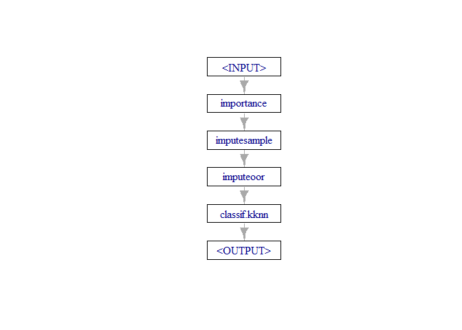

```r
graph$plot()
```

### Solution:

**Click me:**

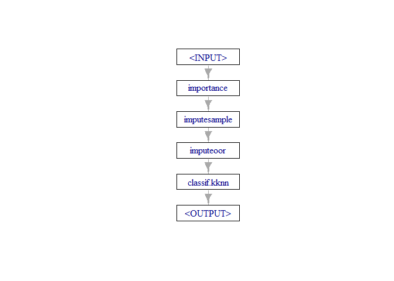

```r
graph = filter %>>%
  impute_integer %>>%
  impute_factor %>>%
  lrn("classif.kknn")

graph$plot()
```

## Performance Assessment

Use 10-fold cross-validation to estimate the classification error of the pipeline stored in the `Graph` on the credit data. Use a seed to make your results reproducible (e.g., `set.seed(7130L`).

**Hint 1:**

Specifically, you need to conduct three steps:

1. Specify a `Resampling` object using `rsmp()` and instantiate the train-test splits.
2. Use this object together with the task and learner specified above as an input to the `resample()` method.
3. Measure the performance with `$aggregate()`.

**Hint 2:**

```r
set.seed(7130L)
resampling = rsmp("cv", ...)
resampling$instantiate(...)
rr = resample(task = ..., learner = ..., resampling = ...)
rr$...()
```

### Solution:

**Click me:**

```r
set.seed(7130L)
resampling = rsmp("cv", folds = 10L)
resampling$instantiate(task)
rr = resample(task = task, learner = graph, resampling = resampling)
rr$aggregate()
## classif.ce
##      0.317
```

## Extra: Different Imputation Technique

Try out a different imputation method for numeric and categorical features: `"imputemode"` which imputes features by computing the mode using the non-missing training data (i.e., it uses the most frequent value for categorical features and the feature value where the distribution has its maximum for numeric features). Does this approach change the overall performance of the previous kNN classifier? Assess this by using the same folds as in the previous exercise.

**Hint 1:**

Specifically, you need to conduct the following steps:

**Hint 2:**

```r
graph2 = filter %>>%
  po("...") %>>%
  lrn("classif.kknn")

rr2 = resample(task = ..., learner = graph2, resampling = ...)
rr2$aggregate(...)
```

### Solution:

**Click me:**

```r
graph2 = filter %>>%
  po("imputemode") %>>%
  lrn("classif.kknn")

set.seed(7130L)
resampling$instantiate(task)
rr2 = resample(task = task, learner = graph2, resampling = resampling)
rr2$aggregate()
## classif.ce
##       0.32

set.seed(7130L)
bench = benchmark(benchmark_grid(list(task), list(graph, graph2), list(resampling)))
bench$aggregate()
```

```
##    nr       task_id                                     learner_id resampling_id iters classif.ce
## 1:  1 german_credit importance.imputesample.imputeoor.classif.kknn            cv    10      0.334
## 2:  2 german_credit             importance.imputemode.classif.kknn            cv    10      0.331
## Hidden columns: resample_result
```

```r
# top 5 features
filter$train(list(task))
```

```
## $output
## <TaskClassif:german_credit> (1000 x 6)
## * Target: credit_risk
## * Properties: twoclass
## * Features (5):
##   - fct (4): installment_rate, other_debtors, property, purpose
##   - int (1): age
```

```r
# features with missing values
miss = sapply(task$data(), function(x) any(is.na(x)))
miss[miss]
```

```
##                 age employment_duration      number_credits
##                TRUE                TRUE                TRUE
```

# Summary

In this exercise sheet, we learned how to set up a `Graph` learner for combining the preprocessing steps with model fitting. We saw a basic pipeline that conducts feature filtering and imputation of missing values before a kNN classifier is fit.

In the upcoming exercise sheet, we will learn how to tune different components of a pipeline such that preprocessing as well as model fitting could be further optimized for the task at hand.